# gg_reclassification_hw

AY

April 27, 2016

Reclassification of the sequences used in the MiSeq_SOP using the greengenes reference instead of silva. Downloaded the August 2013 release of gg_13_8_99 greengenes reference alignment from the mothur website.

I followed and modified the commands found in the MiSeq_SOP (also found in the stability.batch file we downloaded for the class) to fit the greengenes reference. To find the start and end inputs for the region (V4) we wanted, I found [a post on the mothur forum](http://www.mothur.org/forum/viewtopic.php?t=2498#p10529) and aligned the [*E. coli* sequence](http://www.ncbi.nlm.nih.gov/nuccore/174375?report=fasta) they used to the greengenes reference using the same primer set they used since the primers enclosed the V3 and V4 regions.

I used the following command to align the E. coli sequence to the gg reference:

##### align.seqs(fasta=ecoli.16srrna.pcr.fasta, reference=gg_13_8_99.refalign)

Then looked at the summary of the resulting aligned sequence to get an appropriate start and end of where my sequences will be in the reference:

##### summary.seqs(fasta=ecoli.16srrna.pcr.align)

Which summarized the sequences of starting at 1855 and ending at 4051. Then I more or less followed the MiSeq_SOP using start=1855 and end=4051 for the first pcr.seq command to customized the gg database for these sequences:

##### pcr.seqs(fasta=gg_13_8_99.refalign, start=1855, end=4051, keepdots=F, processors=2)

##### system(mv gg_13_8_99.pcr.refalign gg.v3v4.fasta)

##### make.contigs(file=stability.files, processors=4)

Just to double check the contig length, I did summary.seq to confirm that the contigs were still 275 and moved onto the next commands:

##### screen.seqs(fasta=current, group=current, maxambig=0, maxlength=275)

##### unique.seqs(fasta=stability.trim.contigs.good.fasta)

##### count.seqs(name=current, group=current)

Then aligned my sequences to my modified gg reference generated earlier:

##### align.seqs(fasta=current, reference=gg.v3v4.fasta)

Based on the following summary.seq command, the output sequences mostly started at 409 and ended at 2196. The sequences that followed these parameters had a maximum homopolymer length of 6 so I kept the maxhomop option set to 8 for the screen.seq step:

##### summary.seqs(fasta=stability.trim.contigs.good.unique.align, count=stbility.trim.contigs.good.count_table)

##### screen.seqs(fasta=current, count=current, start=409, end=2196, maxhomop=8)

Then followed the MiSeq_SOP using the same parameters:

##### filter.seqs(fasta=current, vertical=T, trump=.)

##### unique.seqs(fasta=current, count=current)

##### pre.cluster(fasta=current, count=current, diffs=2)

##### chimera.uchime(fasta=current, count=current, dereplicate=t)

##### remove.seqs(fasta=current, accnos=current)

##### classify.seqs(fasta=current, count=current, reference=trainset9_032012.pds.fasta, taxonomy=trainset9_032012.pds.tax, cutoff=80)

##### remove.lineage(fasta=current, count=current, taxonomy=current, taxon=Chloroplast-Mitochondria-unknown-Archaea-Eukaryota)

(Skipped the assessing error rates steps.)

##### remove.groups(count=current, fasta=current, taxonomy=current, groups=Mock)

##### cluster.split(fasta=current, count=current, taxonomy=current, splitmethod=classify, taxlevel=4, cutoff=0.15)

Then made the shared file and renamed:

##### make.shared(list=current, count=current, label=0.03)

##### system(mv stability.trim.contigs.good.unique.good.filter.unique.precluster.pick.pick.pick.pick.an.unique_list.shared stability.gg.an.shared)

Also made the taxonomy file and renamed:

##### classify.otu(list=current, count=current, taxonomy=current, label=0.03)

##### system(mv stability.trim.contigs.good.unique.good.filter.unique.precluster.pick.pick.pick.pick.an.unique_list.0.03.cons.taxonomy stability.gg.an.cons.taxonomy)

To quickly compare the differences between the silva (in class) and greengenes classifications, I looked at the rarefaction curves (alpha diversity) for the day 0 and day 150 samples (F3D0 and F3D150).

To get the rarefaction files, I used the rarefaction.single command on the silva and greengenes shared files:

##### rarefaction.single(shared=stability.an.shared, calc=sobs, freq=100)

##### rarefaction.single(shared=stability.gg.an.shared, calc=sobs, freq=100)

Then I used the gglot2 package in RStudio to plot the curves using the following code:

```
## Warning: Removed 128 rows containing missing values (geom_path).
```

```
## Warning: Removed 100 rows containing missing values (geom_path).
```

```
## Warning: Removed 128 rows containing missing values (geom_path).
```

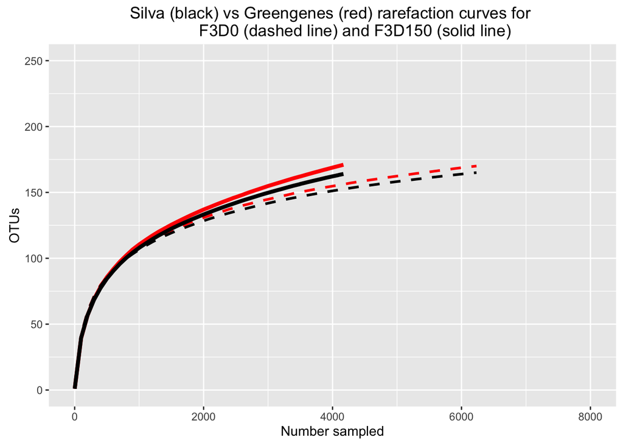

```r
gg_rare <-read.table("stability.gg.an.groups.rarefaction", header=TRUE)
silva_rare <-read.table("stability.an.groups.rarefaction", header=TRUE)
rare_0_150 <- data.frame(gg_rare$numsampled, gg_rare$X0.03.F3D0, gg_rare$X0.03.F3D150, silva_rare$X0.03.F3D0, silva_rare$X0.03.F3D150)
library(ggplot2)
ggplot(rare_0_150, aes(gg_rare.numsampled)) +
  geom_line(aes(y=gg_rare.X0.03.F3D0), linetype = 2, colour="red", size=1) +
  geom_line(aes(y=gg_rare.X0.03.F3D150), colour="red", size=1.5) +
  geom_line(aes(y=silva_rare.X0.03.F3D0), linetype = 2, colour="black", size=1) +
  geom_line(aes(y=silva_rare.X0.03.F3D150), colour="black", size=1.5) +
  ggtitle("Silva (black) vs Greengenes (red) rarefaction curves for
          F3D0 (dashed line) and F3D150 (solid line)") +
  scale_x_continuous(limits = c(0,8000)) +
  scale_y_continuous(limits = c(0,250)) +
  labs(x="Number sampled", y="OTUs")
```

I think the warning messages are due to “NA” values in the data frame but don’t affect the graph. There seems to be a slight increase in OTUs “identified” with the greengenes database compared to the silva one but the curves are pretty similar for samples for both days.

Then I quickly looked at beta diversity differences using the venn command but first determined the greengenes subsample size of 2440:

##### venn(shared=stability.an.0.03.subsample.shared, groups=F3D0-F3D150)

##### venn(shared=stability.gg.an.0.03.subsample.shared, groups=F3D0-F3D150)

Resulting in the following venn diagrams:

### Silva:

[figure not shown]

### Greengenes:

[figure not shown]